# A tutorial on variant filtering on FFPE samples using Ideafix

Maitena Tellaetxe Abete

Last updated: 2021-09-13

## What is Ideafix?

Ideafix is a package for variant refinement designed specifically for FFPE DNA sequencing data.

DNA obtained from FFPE samples suffers from significant levels of fragmentation, denaturation, cross-linking and chemical modifications, all of which can contribute to sequence artefacts. One of the most prevalent artefacts is deamination of cytosine residues to uracil, which, as a consequence of successive PCR amplification rounds, results in the C$>$T (or G$>$A anti-sense strand) variant. So far, there is no gold-standard technique to distinguish real variants from FFPE artifacts.

Ideafix is a decision tree-based variant refinement tool that identifies cytosine deaminations in lists of variants (vcf files) found in DNA sequencing data from FFPE specimens. It takes as an input a vcf file resulting from variant calling on an bam file from FFPE data, looks for C:G $>$ T:A variants with a VAF $<$ 30% and identifies which of them are formalin-induced deaminations or artefacts. Ideafix outputs a table indicating the class label and the score for each variant, and allows the user to finally append the annotations to the original vcf file or simply output the table to a separate text file.

Ideafix is a tool based on fully supervised learning and in fact uses two different models to do the variant classification: XGBoost or Random Forest (RF). Both models show outstanding performance (AUC $>$ 0.95) so the user can decide which one to use indistinctively.

As a fully supervised model, Ideafix is trained over a series of 23 variant descriptors related to allele-frequency, sequencing quality, fragment length and read-orientation bias, among others. One of the main contributing feature to the model is FDeamC, which is a numeric descriptor that reflects read-pair orientation bias. The following figure summarizes what read-pair orientation bias is, why it arises and how it can be relevant for identifying cytosine deaminations:

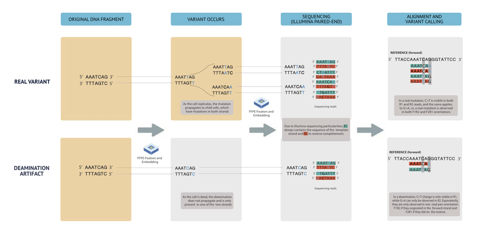

Origin and display of read pair orientation bias in sequencing reads along time

Ideafix is described in detail in an article that is currently under review and we will provide the link to it as long as it gets published.

## Installation

Ideafix can be installed from Github as follows:

```r
if (!require("devtools")) install.packages("devtools")
devtools::install_github("mmaitenat/ideafix", build_vignettes = TRUE)
```

Beware that `devtools::install_github()` does not build vignettes by default so we need to force it by setting `build_vignettes` to `TRUE`.

Note that installation may take a while as the size of the package is in the order of hundreds of Mbs.

## Requirements

Ideafix needs the following programs to run:

- bcftools
- samtools (>1.8)

It also depends on the following packages:

- h2o 3.22.1.1

It is important to note that the h2o version must necessarily be that one. To install this specific version, we recommend that you install the version from source as follows:

```r
h2o_pck_url <- "https://cran.r-project.org/src/contrib/Archive/h2o/h2o_3.22.1.1.tar.gz"
install.packages(h2o_pck_url, repos = NULL, type = "source")
```

Ideafix also needs the following files:

- VCF file obtained from an FFPE specimen. Variant calling needs to be run with Mutect2, with strand bias annotation enabled. It can be either a tumor-only or a normal-tumor paired variant calling.
- Fasta file of the genome data was aligned to.

Finally, Ideafix is only available for Linux and Mac systems.

## Workflow

Ideafix classifies the C:G $>$ T:A variants with a VAF $<$ 30% present in a vcf file into deaminations or non-deaminations following these steps:

0. Variant calling using `Mutect2`
1. Extraction of variant descriptors
2. Classification of variants
3. Analysis of the results (optional)
4. Annotation of class label into original vcf file or to separate file (optional)

Ideafix allows to perform steps 1-4, and so the user needs to proceed previously with step 0. Below are explained these steps in more detail.

### Step 0: Variant calling using Mutect2

Ideafix requires that variants in the FFPE sample to be analyzed have been called using `Mutect2` caller with strand bias annotation enabled. `Mutect2` can be run either in tumor-only or tumor-normal paired mode. For tumor-only mode, this would be as follows:

```bash
gatk4="java -jar /opt/gatk-4.0.8.1/gatk-package-4.0.8.1-local.jar"
REF=~/Data/hg19/ucsc.hg19.fasta
bamfile=mysample.bam
sample_id=mysample
vcf_filename=mysample.vcf

$gatk4 Mutect2 \
     -R $REF \
     -I $bamfile \
     -tumor $sample_id \
     -O mysample0.vcf \
     --annotation StrandBiasBySample

$gatk4 FilterMutectCalls \
     -V mysample0.vcf \
     -O $vcf_filename
```

The code is almost the same in case we are doing a paired variant calling:

```bash
tumor_bamfile=mysample_tumor.bam
tumor_sample_id=mysample_tumor
normal_bamfile=mysample_normal.bam
normal_sample_id=mysample_normal
vcf_filename=mysample.vcf

$gatk4 Mutect2 \
    -R $REF \
    -I $tumor_bamfile \
    -tumor $tumor_sample_id \
    -I $normal_bamfile \
    -normal $normal_sample_id \
    -O mysample0.vcf \
    --annotation StrandBiasBySample

$gatk4 FilterMutectCalls \
     -V mysample0.vcf \
     -O $vcf_filename
```

The `Mutect2` command runs the variant calling; the `FilterMutectCalls` applies filter-marks to the raw output of `Mutect2`. Note that `FilterMutectCalls` does not remove any variant from the vcf file; it simply adds a filter-mark to each of them: if it considers they are putative variants, it will be PASS, and if not PASS, the reason why it considers it is an artefact.

Ideafix only works on the PASS-filtering variants, as the rest are already marked as artifacts by the variant calling algorithm.

### Step 1: Extraction of variant descriptors

Once the vcf file is ready, we can start off using Ideafix. Let us load the library:

```r
library(ideafix)
```

The first step in the variant refinement is to extract the descriptors of the variants found in the vcf file. Ideafix extracts these descriptors from two files: the vcf file itself, and the fasta file to which data was aligned to.

For this tutorial, we have created two toy files: a vcf file (generated by selecting the variants in chromosome 15 from the vcf file generated as in Step 0) and the fasta file. As they are too heavy to be included in the package, we have made them available to you through [this link](http://www.sc.ehu.es/ccwbayes/members/maitena/SampleData.zip).

Once you download them, you first need to extract the fasta file, which is compressed in tar.gz format. For doing so, you just need to type the following in the terminal, from the SampleData directory:

```bash
tar -xzvf chr15.fasta.tar.gz
```

Or, if you prefer to use R:

```r
sampleData_dir <- "~/Downloads/SampleData" # change here to the correct SampleData directory
untar_cmd <- sprintf("tar -xzvf %s", file.path(sampleData_dir, "chr15.fasta.tar.gz"))
system(untar_cmd)
```

Once data is extracted, you must provide the full path to both files in the variables `vcf_filename` and `ref_genome`, as in this example:

```r
vcf_filename <- "~/Downloads/SampleData/mysample_chr15.vcf"
ref_genome <- "~/Downloads/SampleData/chr15.fasta"
```

The final step is to obtain the descriptors as follows:

```r
descriptors <- get_descriptors(vcf_filename = vcf_filename, fasta_filename = ref_genome)
```

In this example, the resulting object is a data frame consisting of 28 columns or features for each variant in the vcf file. You can have a quick look on the data with the following command:

```r
dplyr::glimpse(descriptors)
```

```
#> Observations: 2,508
#> Variables: 28
#> $ allele.freq        <dbl> 0.049, 0.083, 0.166, 0.202, 0.116, 0.048, 0.259, 0…
#> $ alt.bases          <dbl> 8, 16, 13, 10, 17, 8, 15, 9, 7, 3, 25, 6, 9, 4, 11…
#> $ norm.alt.bases     <dbl> 0.04878049, 0.07843137, 0.07065217, 0.20000000, 0.…
#> $ ref.bases          <dbl> 156, 188, 171, 40, 149, 160, 44, 46, 281, 21, 95, …
#> $ norm.ref.bases     <dbl> 0.9512195, 0.9215686, 0.9293478, 0.8000000, 0.8975…
#> $ ref.allele         <chr> "C", "C", "C", "C", "C", "C", "C", "G", "G", "G", …
#> $ alt.allele         <chr> "T", "T", "T", "T", "T", "T", "T", "A", "A", "A", …
#> $ base.qual          <dbl> 38, 39, 39, 39, 40, 36, 38, 37, 41, 35, 37, 39, 40…
#> $ base.qual.frac     <dbl> 0.9500000, 1.0540541, 1.0540541, 1.0000000, 1.0526…
#> $ frag.length        <dbl> 170, 115, 134, 108, 122, 213, 142, 91, 128, 112, 1…
#> $ pos.from.end       <dbl> 32, 15, 12, 31, 27, 6, 35, 25, 32, 36, 23, 9, 27, …
#> $ map.qual           <dbl> 60, 60, 60, 55, 60, 47, 49, 47, 40, 49, 40, 50, 60…
#> $ FdeamC             <dbl> 0, 1, 1, 1, 0, 0, 1, 1, 1, 0, 1, 1, 1, 1, 0, 0, 1,…
#> $ SOB                <dbl> -1, 1, 1, 1, -1, -1, 1, -1, -1, 1, 1, -1, -1, -1, …
#> $ SBGuo              <dbl> 0.9437865, 1.6585113, 1.2104734, 0.4166667, 1.3606…
#> $ SBGATK             <dbl> 0.06628601, 0.14115194, 0.09202808, 0.26041667, 0.…
#> $ id                 <chr> "chr15:20170083", "chr15:20170321", "chr15:2017037…
#> $ both.reads.aligned <dbl> 1, 1, 1, 1, 1, 1, 1, 1, 1, 1, 1, 1, 1, 1, 1, 1, 1,…
#> $ norm.pos.from.end  <dbl> 0.18823529, 0.13043478, 0.08955224, 0.28703704, 0.…
#> $ current            <chr> "C", "C", "C", "C", "C", "C", "C", "G", "G", "G", …
#> $ bases              <fct> AGCCC, GACCA, CTCTC, TACTA, ACCAA, ATCTT, AGCGG, G…
#> $ before.2           <chr> "A", "G", "C", "T", "A", "A", "A", "G", "C", "G", …
#> $ before.1           <chr> "G", "A", "T", "A", "C", "T", "G", "A", "C", "G", …
#> $ after.1            <chr> "C", "C", "T", "T", "A", "T", "G", "C", "A", "C", …
#> $ after.2            <chr> "C", "A", "C", "A", "A", "T", "G", "C", "T", "A", …
#> $ before             <chr> "AG", "GA", "CT", "TA", "AC", "AT", "AG", "GA", "C…
#> $ after              <chr> "CC", "CA", "TC", "TA", "AA", "TT", "GG", "CC", "A…
#> $ is.repeat.region   <lgl> FALSE, FALSE, FALSE, FALSE, FALSE, FALSE, FALSE, F…
```

One can note that the `descriptors` variable contains 2,508 variants instead of the original 21,699 in mysample_chr15.vcf. This is because only these 2,508 were GATK PASS-filtering C:G > T:A variants with a VAF < 30%.